# Intro to DS - Hypothesis Tests, T-test, 2-sample T-test, ANOVA, Chi-squared

GWU Intro to Data Science DATS 6101

2022-10-13

# HW Assignment - Hypothesis Testing

This exercise uses the same graduate school admissions dataset from last homework. The dataset is called `gradAdmit` on api.regression.fit, or as a local file `LogRegAdmit.csv`.

The variables in the dataset are:

- `admit`: 0 or 1 (False or True)
- `gre`: gre score
- `gpa`: grade point average at undergraduate level
- `rank`: the ranking of the applicant’s undergraduate institute, 1, 2, 3, or 4

## Grad School Admissions

### Question 1

**Same as last homework, import the dataset as *Adata*, and make sure the data type for the variables are set properly for categorical variables.**

```r
# Adata = api_rfit(   )
Adata = data.frame(read.csv("LogRegAdmit.csv"))
Adata$admit = as.factor(Adata$admit)
Adata$rank = as.factor(Adata$rank)
Adata
```

### Question 2

**Using the `outlierKD2()` function, identify and flag as NA the outliers for `gre` and `gpa`. Save the resulting dataframe as *Adata2*. This will require multiple lines of code – you need to remove outliers for one variable at a time. How many NA values are in `gre` and in `gpa` with the resulting dataframe *Adata2*?**

```r
out_gpa = outlierKD2(Adata, var = gre, rm = TRUE)
```

```
## Outliers identified: 4
## Proportion (%) of outliers: 1
## Mean of the outliers: 280
## Mean without removing outliers: 588
## Mean if we remove outliers: 591
## Outliers successfully removed
```

```r
Adata2 = outlierKD2(out_gpa, var = gpa, rm = TRUE)
```

[figure not shown]

```
## Outliers identified: 1
## Proportion (%) of outliers: 0.3
## Mean of the outliers: 2.26
## Mean without removing outliers: 3.39
## Mean if we remove outliers: 3.39
## Outliers successfully removed
```

```r
cat("NA values in 'gre': ", sum(is.na(Adata2$gre)))
```

```
## NA values in 'gre':  4
```

```r
cat("NA values in 'gpa': ", sum(is.na(Adata2$gpa)))
```

```
## NA values in 'gpa':  1
```

[figure not shown]

There are **4** NA values in ‘gre’ and **1** in ‘gpa’ for resulting dataframe *Adata2*.

### Question 3

**Like last time, separate the data into two subsets again: one for admitted and one for rejected.**

```r
adata2_adm = subset(Adata2, admit == 1)
adata2_rej = subset(Adata2, admit == 0)
```

### Question 4

**We were a little careless last time. Let us check for normality on the numerical variables. Produce histograms (use `ggplot()`) and QQ-plots (use `qqnorm()`) to check the distributions of the quantitative variables for the admitted and rejected subsets. Make a brief comment on the results.**

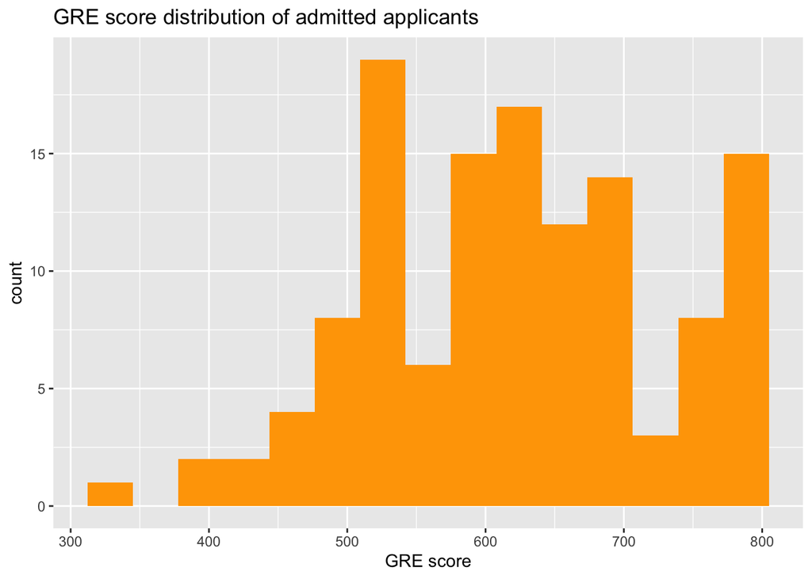

```r
library(ggplot2)

ggplot(adata2_adm, aes(x = gre)) + geom_histogram(bins=15, fill="orange") + labs(title = "GRE score distribution of admitted applicants", x = "GRE score")
```

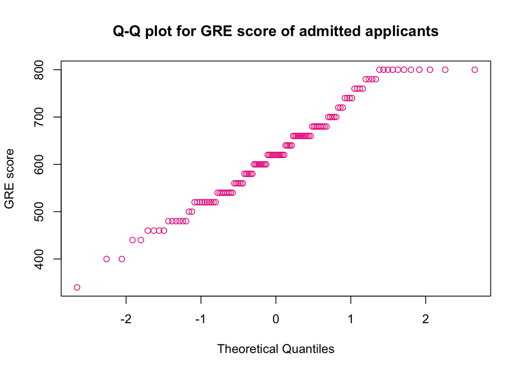

```r
qqnorm(adata2_adm$gre, main="Q-Q plot for GRE score of admitted applicants", ylab="GRE score", col='#E7298A', datax=F)
```

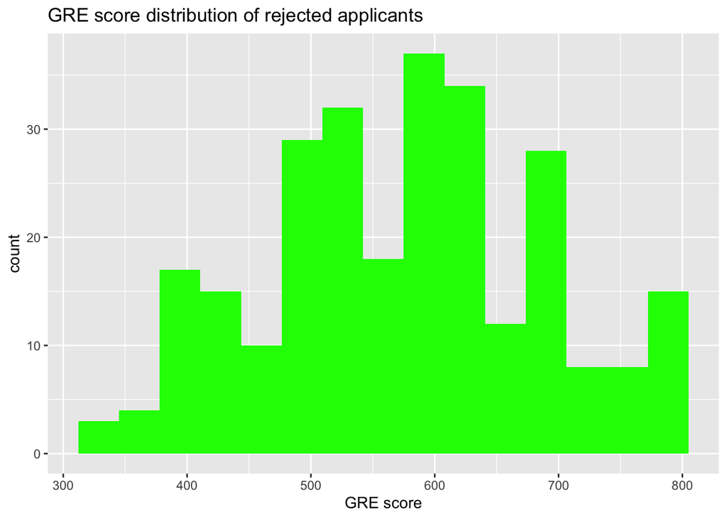

```r
ggplot(adata2_rej, aes(x = gre)) + geom_histogram(bins=15, fill="green") + labs(title = "GRE score distribution of rejected applicants", x = "GRE score")
```

[figure not shown]

```r
qqnorm(adata2_adm$gre, main="Q-Q plot for GRE score of rejected applicants", ylab="GRE score", col='gold', datax=F)
```

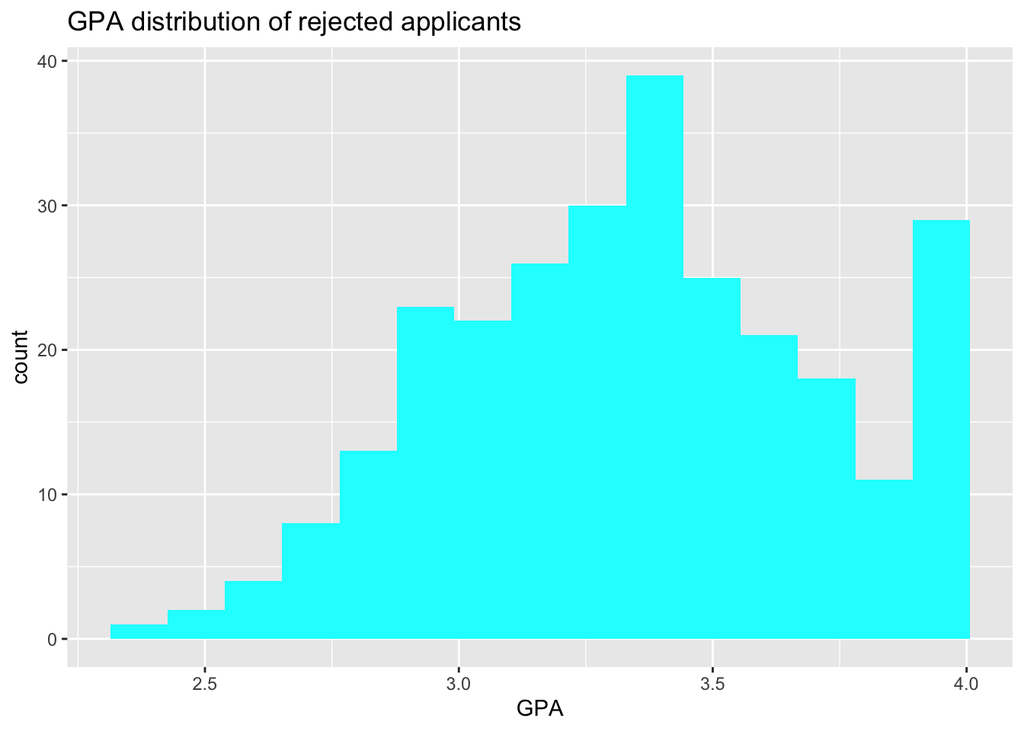

```r
ggplot(adata2_rej, aes(x = gpa)) + geom_histogram(bins=15, fill="cyan") + labs(title = "GPA distribution of rejected applicants", x = "GPA")
```

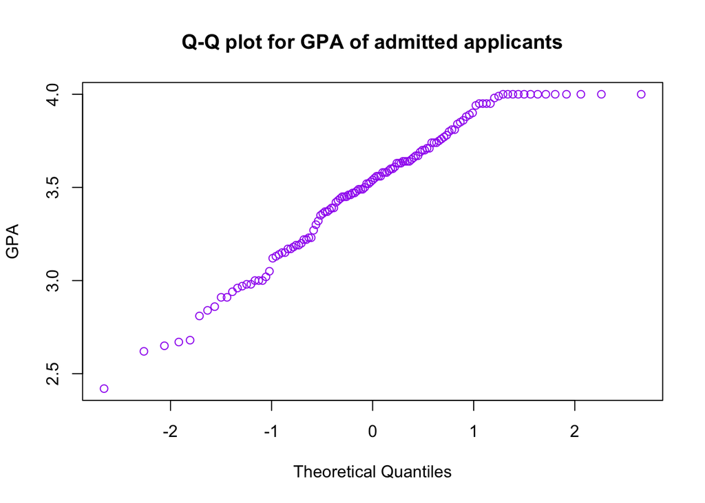

```r
qqnorm(adata2_adm$gpa, main="Q-Q plot for GPA of admitted applicants", ylab="GPA", col='purple', datax=F)
```

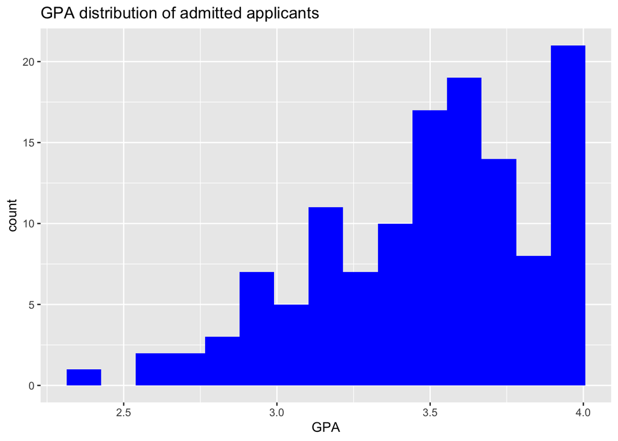

```r
ggplot(adata2_adm, aes(x = gpa)) + geom_histogram(bins=15, fill="blue") + labs(title = "GPA distribution of admitted applicants", x = "GPA")
```

[figure not shown]

```r
qqnorm(adata2_adm$gpa, main="Q-Q plot for GPA of rejected applicants", ylab="GPA", col='red', datax=F)
```

### Question 5

**Do the two subsets have different `gre` averages and `gpa` averages? Use the standard $\alpha$ = 0.05. What are the p-values for the test on `gre` and `gpa`? What are your conclusions from the tests?**

```r
ttest_gre = t.test(x = adata2_adm$gre, y = adata2_rej$gre, conf.level = 0.95)

ttest_gpa = t.test(x = adata2_adm$gpa, y = adata2_rej$gpa,conf.level = 0.95)

ttest_gre$p.value
```

```
## [1] 0.000139
```

```r
ttest_gpa$p.value
```

```
## [1] 0.000458
```

### Question 6

**With the dataset *Adata2*, construct a contingency table between rank and admit. Are these two variables qualitative or quantitative?**

```r
contable_adata = table(Adata2$rank, Adata2$admit, dnn=c("rank", "admit"))
contable_adata
```

```
##     admit
## rank  0  1
##    1 28 33
##    2 97 54
##    3 93 28
##    4 55 12
```

### Question 7

**Find out whether rank is independent of admission, according to the contingency table above.**

```r
chisq.test(contable_adata)
```

```
##
##  Pearson's Chi-squared test
##
## data:  contable_adata
## X-squared = 25, df = 3, p-value = 1e-05
```

### Question 8

**From *Adata2*, test whether students from the four ranks have the same average `gre` or not. And also test if they have the same average `gpa` or not. Remember that if they are not all the same, you will need to follow up with a post hoc test. Make brief comments on your results.**

```r
rank1 <- subset(Adata2, rank==1)
rank2 <- subset(Adata2, rank==2)
rank3 <- subset(Adata2, rank==3)
rank4 <- subset(Adata2, rank==4)

# avg of gre
mean(rank1$gre, na.rm = TRUE)
```

```
## [1] 612
```

```r
mean(rank2$gre, na.rm = TRUE)
```

```
## [1] 598
```

```r
mean(rank3$gre, na.rm = TRUE)
```

```
## [1] 580
```

```r
mean(rank4$gre, na.rm = TRUE)
```

```
## [1] 574
```

```r
# avg of gpa
mean(rank1$gpa, na.rm = TRUE)
```

```
## [1] 3.45
```

```r
mean(rank2$gpa, na.rm = TRUE)
```

```
## [1] 3.36
```

```r
mean(rank3$gpa, na.rm = TRUE)
```

```
## [1] 3.43
```

```r
mean(rank4$gpa, na.rm = TRUE)
```

```
## [1] 3.33
```

```r
anovaResgre = aov(gre ~ rank, data=Adata2)
summary(anovaResgre)
```

```
##              Df  Sum Sq Mean Sq F value Pr(>F)
## rank          3   66231   22077    1.78   0.15
## Residuals   392 4870710   12425
## 4 observations deleted due to missingness
```

```r
anovaResgpa = aov(gpa ~ rank, data=Adata2)
summary(anovaResgpa)
```

```
##              Df Sum Sq Mean Sq F value Pr(>F)
## rank          3    0.8   0.263    1.86   0.14
## Residuals   395   55.7   0.141
## 1 observation deleted due to missingness
```

Difference between the mean of the groups is small and p-value is greater than 0.05, thus we cannot reject null hypothesis, that is, they have the same average gre and gpa for all the ranks.